# Task 3

## 3. Apply the Box-Cox transformation to the sales data to stabilize variance.

Normally distribute the data by using $\lambda$ that is varies over real numbers

$$if\ \lambda \neq 0\: y(\lambda) = \frac{y^{\lambda} - 1}{\lambda}\\
if\ \lambda = 0 : y(\lambda) = \log {y}$$

The **log-likelihood** is used to evaluate how well different lambda values normalize the variance and approximate a normal distribution in the transformed data.

### Plot the transformed data and interpret how the transformation impacts the distribution and stationarity of the data.

#### Find the lambda

```r
library(MASS)
bx_cox = boxcox(lm(timeseries_df$Sales~1))
```

[figure not shown]

```r
lambda = bx_cox$x[which.max(bx_cox$y)]
lambda
```

```
## [1] 0.7070707
```

- **Zero** is outside the confidence interval of the optimal `lambda`
- The peak of this curve indicates the lambda value that maximizes the log-likelihood
- **Vertical Lines** represent the confidence interval for $\lambda$
- 95% represents the critical value for identifying optimum $\lambda$

A $\lambda = 0.7070707$ indicates that a linear model could fit the data adequately while stabilizing variance to make the distribution normal.

The large confidence interval indicates that there is high flexibility in choosing lambda. Because of the flexibility and the $\lambda \approx 1$ applying box-cox transformation may not change the data much.

#### Apply Box-cox

```r
timeseries_df$transformed = ((timeseries_df$Sales ^ lambda) - 1)/ lambda
head(timeseries_df)
```

```
##       Time Sales transformed
## 1 2017.000  10.2    5.891868
## 2 2017.083  10.8    6.193194
## 3 2017.167  11.0    6.292538
## 4 2017.250  11.5    6.538614
## 5 2017.333  12.0    6.781576
## 6 2017.417  12.5    7.021588
```

#### Plot

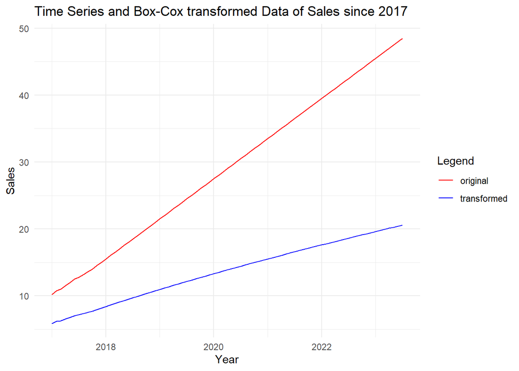

```r
plot_data_2 = timeseries_df

ggplot(plot_data_2, aes(x = Time, group = 1)) +
  geom_line(aes(y = Sales, color = "original")) +
  geom_line(aes(y = transformed, color = "transformed")) +
  labs(title = "Time Series and Box-Cox transformed Data of Sales since 2017",
       x = "Year",
       y = "Sales") +
   scale_color_manual(name = "Legend", values = c("original" = "red", "transformed"= "blue"))+
  theme_minimal()
```

## 4. Perform the ADF test on the transformed sales data to confirm stationarity

### Interpret the results and compare them with those from Question 2 to assess the effectiveness of the Box-Cox transformation

```r
adf.test(timeseries_df$transformed, k = k)
```

```
##
##  Augmented Dickey-Fuller Test
##
## data:  timeseries_df$transformed
## Dickey-Fuller = 0.13999, Lag order = 4, p-value = 0.99
## alternative hypothesis: stationary
```

- **Positive Dickey-Fuller** –strong support for $H_0$
- **P-value** – $\geq 0.05$ fail to reject $H_0$

**Conclude that the new generated data is not stationary**

#### Conclusions

reason

1. optimum $\lambda$ was selected
2. The transformation has not achieved stationarity
3. Because of this a conclusion that the data may have seasonality on top of the trend was made.

The **variance-stabilizing** does not sufficiently achieve stationarity

## 5. Compute and plot the Autocorrelation Function (ACF) for up to 20 lags of the transformed sales data.

### mean of $Y_t$

```r
mean_yt = mean(timeseries_df$Sales)
mean_yt
```

```
## [1] 29.0519
```

### Autocorrelation data

```r
auto_cor = timeseries_df[, c(1, 3)]
```

### Auto-corr function

autocorrelation $\rho_k$ for $k = 0, 1, 2, ..., 20$ can be found by

$$\rho_k = \frac{\sum^{T}_{t = k + 1} (Y_t - \mu) (Y_{t-k} - \mu)
}{\sum^{T}_{t = 1} (Y_t - \mu)^2}$$

```r
auto_corr_func = function(data, k){
  n = length(data)
  mu = mean(data)

  # T = n
  # Y_t - mu = y_{k+ 1}, ..., y_{n} like in class (91, 45, 89,...) are moved 1 step below for eack new k the y column. new data mean variation
  # Y_{t -k} - original column but not last value y_1, ..., y_{n-k}. original mean variation
  # denominator is just the original column variance
  num = sum(((data[(k+1): n]) - mu)  *((data[1: (n-k)]) - mu))
  denom = sum((data -mu)^2)

  autocorr = num/denom

  return(autocorr)
}
```

### fit the auto corr

```r
for(i in seq(0,20)){
  col_name = paste("ACF_k_", i)
  auto_cor[[col_name]] = auto_corr_func(auto_cor$transformed, i)
}
```

### check

```r
head(auto_cor)
```

```
##       Time transformed ACF_k_ 0  ACF_k_ 1  ACF_k_ 2  ACF_k_ 3  ACF_k_ 4
## 1 2017.000    5.891868        1 0.9620024 0.9244976 0.8864183 0.8485756
## 2 2017.083    6.193194        1 0.9620024 0.9244976 0.8864183 0.8485756
## 3 2017.167    6.292538        1 0.9620024 0.9244976 0.8864183 0.8485756
## 4 2017.250    6.538614        1 0.9620024 0.9244976 0.8864183 0.8485756
## 5 2017.333    6.781576        1 0.9620024 0.9244976 0.8864183 0.8485756
## 6 2017.417    7.021588        1 0.9620024 0.9244976 0.8864183 0.8485756
##    ACF_k_ 5  ACF_k_ 6  ACF_k_ 7  ACF_k_ 8  ACF_k_ 9 ACF_k_ 10 ACF_k_ 11
## 1 0.8109783 0.7736503 0.7360888 0.6985606 0.6610841 0.6236717 0.5865876
## 2 0.8109783 0.7736503 0.7360888 0.6985606 0.6610841 0.6236717 0.5865876
## 3 0.8109783 0.7736503 0.7360888 0.6985606 0.6610841 0.6236717 0.5865876
## 4 0.8109783 0.7736503 0.7360888 0.6985606 0.6610841 0.6236717 0.5865876
## 5 0.8109783 0.7736503 0.7360888 0.6985606 0.6610841 0.6236717 0.5865876
## 6 0.8109783 0.7736503 0.7360888 0.6985606 0.6610841 0.6236717 0.5865876
##   ACF_k_ 12 ACF_k_ 13 ACF_k_ 14 ACF_k_ 15 ACF_k_ 16 ACF_k_ 17 ACF_k_ 18
## 1 0.5498495 0.5134755 0.4774839 0.4418934 0.4067228 0.3719915 0.3377187
## 2 0.5498495 0.5134755 0.4774839 0.4418934 0.4067228 0.3719915 0.3377187
## 3 0.5498495 0.5134755 0.4774839 0.4418934 0.4067228 0.3719915 0.3377187
## 4 0.5498495 0.5134755 0.4774839 0.4418934 0.4067228 0.3719915 0.3377187
## 5 0.5498495 0.5134755 0.4774839 0.4418934 0.4067228 0.3719915 0.3377187
## 6 0.5498495 0.5134755 0.4774839 0.4418934 0.4067228 0.3719915 0.3377187
##   ACF_k_ 19 ACF_k_ 20
## 1  0.303924 0.2706274
## 2  0.303924 0.2706274
## 3  0.303924 0.2706274
## 4  0.303924 0.2706274
## 5  0.303924 0.2706274
## 6  0.303924 0.2706274
```

```r
tail(auto_cor)
```

```
##        Time transformed ACF_k_ 0  ACF_k_ 1  ACF_k_ 2  ACF_k_ 3  ACF_k_ 4
## 74 2023.083    19.78028        1 0.9620024 0.9244976 0.8864183 0.8485756
## 75 2023.167    19.94291        1 0.9620024 0.9244976 0.8864183 0.8485756
## 76 2023.250    20.10504        1 0.9620024 0.9244976 0.8864183 0.8485756
## 77 2023.333    20.26665        1 0.9620024 0.9244976 0.8864183 0.8485756
## 78 2023.417    20.42777        1 0.9620024 0.9244976 0.8864183 0.8485756
## 79 2023.500    20.58840        1 0.9620024 0.9244976 0.8864183 0.8485756
##     ACF_k_ 5  ACF_k_ 6  ACF_k_ 7  ACF_k_ 8  ACF_k_ 9 ACF_k_ 10 ACF_k_ 11
## 74 0.8109783 0.7736503 0.7360888 0.6985606 0.6610841 0.6236717 0.5865876
## 75 0.8109783 0.7736503 0.7360888 0.6985606 0.6610841 0.6236717 0.5865876
## 76 0.8109783 0.7736503 0.7360888 0.6985606 0.6610841 0.6236717 0.5865876
## 77 0.8109783 0.7736503 0.7360888 0.6985606 0.6610841 0.6236717 0.5865876
## 78 0.8109783 0.7736503 0.7360888 0.6985606 0.6610841 0.6236717 0.5865876
## 79 0.8109783 0.7736503 0.7360888 0.6985606 0.6610841 0.6236717 0.5865876
##    ACF_k_ 12 ACF_k_ 13 ACF_k_ 14 ACF_k_ 15 ACF_k_ 16 ACF_k_ 17 ACF_k_ 18
## 74 0.5498495 0.5134755 0.4774839 0.4418934 0.4067228 0.3719915 0.3377187
## 75 0.5498495 0.5134755 0.4774839 0.4418934 0.4067228 0.3719915 0.3377187
## 76 0.5498495 0.5134755 0.4774839 0.4418934 0.4067228 0.3719915 0.3377187
## 77 0.5498495 0.5134755 0.4774839 0.4418934 0.4067228 0.3719915 0.3377187
## 78 0.5498495 0.5134755 0.4774839 0.4418934 0.4067228 0.3719915 0.3377187
## 79 0.5498495 0.5134755 0.4774839 0.4418934 0.4067228 0.3719915 0.3377187
##    ACF_k_ 19 ACF_k_ 20
## 74  0.303924 0.2706274
## 75  0.303924 0.2706274
## 76  0.303924 0.2706274
## 77  0.303924 0.2706274
## 78  0.303924 0.2706274
## 79  0.303924 0.2706274
```

The values in the ACF_k columns are the same so taking one row should be enough for creating the ACF plot.

### Plot

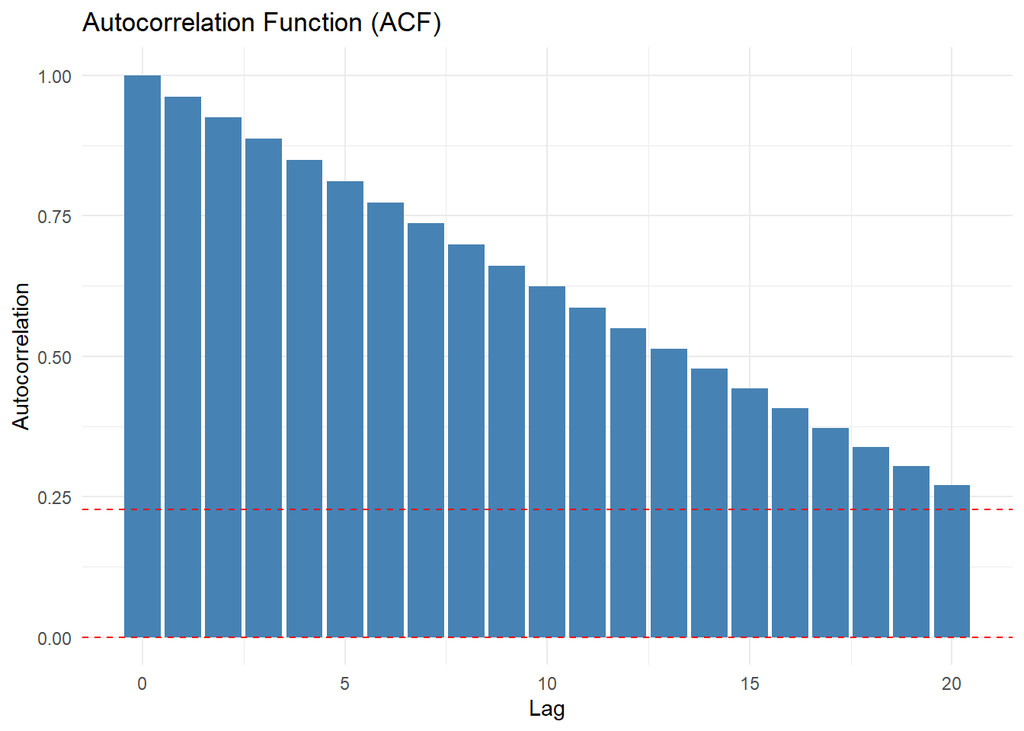

```r
library(stats)
plot_data_3 = data.frame(Lag = seq(0,20),
                         ACF = unlist(auto_cor[, 3:ncol(auto_cor)][1,], use.names = FALSE))

ggplot(plot_data_3, aes(x = Lag, y = ACF)) +
  geom_bar(stat = "identity", fill = "steelblue") +
  geom_hline(yintercept = 0, linetype = "dashed", color = "red") +
  geom_hline(yintercept = sd(plot_data_3$ACF), linetype = "dashed", color = "red") +
  labs(
    title = "Autocorrelation Function (ACF)",
    x = "Lag",
    y = "Autocorrelation") +
  theme_minimal()
```

# References

cran.r-project.org. (2020). *Package “tseries” title time series analysis and computational finance*. https://cran.r-project.org/web/packages/tseries/tseries.pdf

Jim. (2022, October 23). *Box cox transformation in R | r-bloggers*. R-Bloggers.com. https://www.r-bloggers.com/2022/10/box-cox-transformation-in-r/

RDocumentation. (n.d.). *Adf.test function - rdocumentation*. Www.rdocumentation.org. Retrieved July 13, 2024, from https://www.rdocumentation.org/packages/tseries/versions/0.10-56/topics/adf.test

RDocumentation. (n.d.-b). *Ts function | R documentation*. Www.rdocumentation.org. https://www.rdocumentation.org/packages/stats/versions/3.6.2/topics/ts